# Лабораторная работа №9

## 2. Работа со встроенным редактором файлов в Midnight Commander

Перехожу в папку, в меню пользователя выбираю сделать что-то в текущем файле (по сути в каталоге).

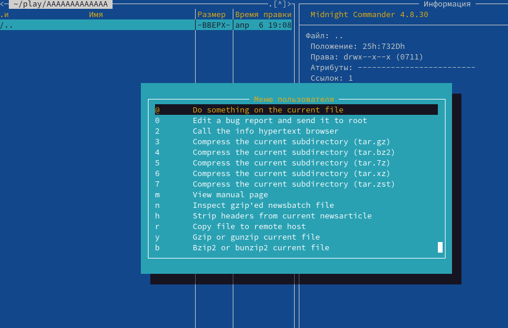

Сделать что-то в текущем файле

## 2. Работа со встроенным редактором файлов в Midnight Commander

Ввожу команду для создания файла.

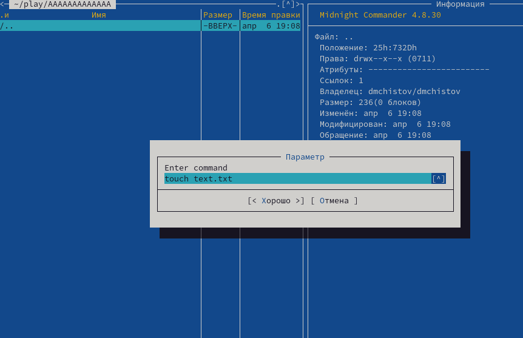

Создаю файл

## 2. Работа со встроенным редактором файлов в Midnight Commander

Файл успешно создан.

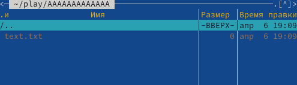

Создаю файл - успешно

## 2. Работа со встроенным редактором файлов в Midnight Commander

Перехожу в него, вставляю текст из pdf файла Лаборторной работы №9.

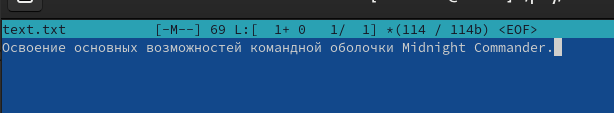

Работа с файлом

## 2. Работа со встроенным редактором файлов в Midnight Commander

Удаляю строку в тексте с помощью ctrl+y.

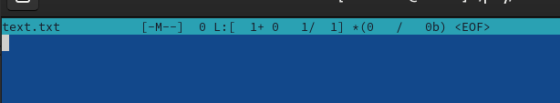

Работа с файлом

## 2. Работа со встроенным редактором файлов в Midnight Commander

Нужно скопировать текст. Выделю нужный текст.

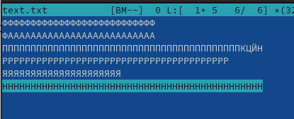

Работа с файлом

## 2. Работа со встроенным редактором файлов в Midnight Commander

Горячими клавишами вставляю текст на новую строку.

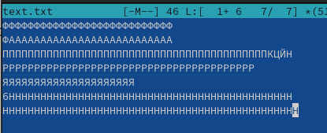

Работа с файлом

## 2. Работа со встроенным редактором файлов в Midnight Commander

Нужно переместить текст на дргугю строку. Выделяю текст.

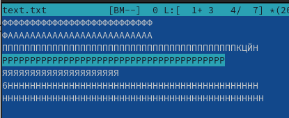

Работа с файлом

## 2. Работа со встроенным редактором файлов в Midnight Commander

Перемещаю текст.

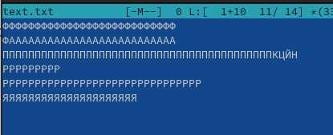

Работа с файлом

## 2. Работа со встроенным редактором файлов в Midnight Commander

Сохраняю файл.

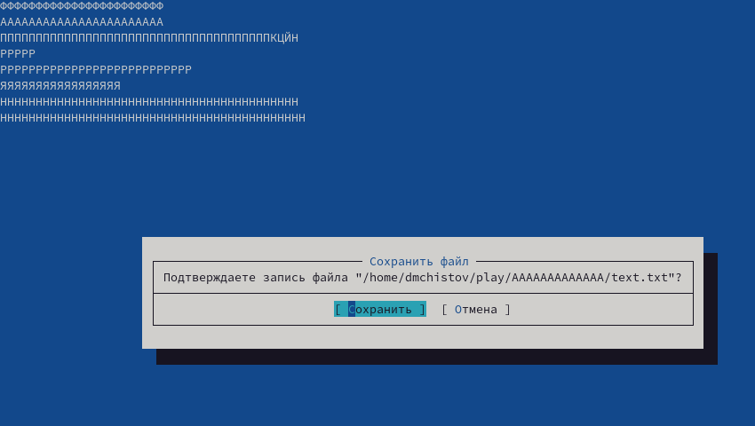

Работа с файлом

## 2. Работа со встроенным редактором файлов в Midnight Commander

Отменяю предыдущее действие с помощью ctrl+u.

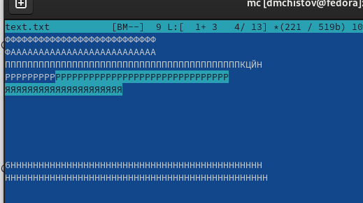

Работа с файлом

## 2. Работа со встроенным редактором файлов в Midnight Commander

С помощью PgUP пермещаюсь в начало файла.

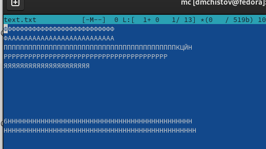

Работа с файлом

## 2. Работа со встроенным редактором файлов в Midnight Commander

С помощью PgDOWN пермещаюсь в конец файла.

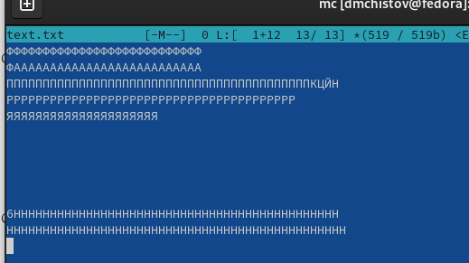

Работа с файлом

## 2. Работа со встроенным редактором файлов в Midnight Commander

Открываю файл .md, чтобы у меня выделялся синтаксис Markdown.

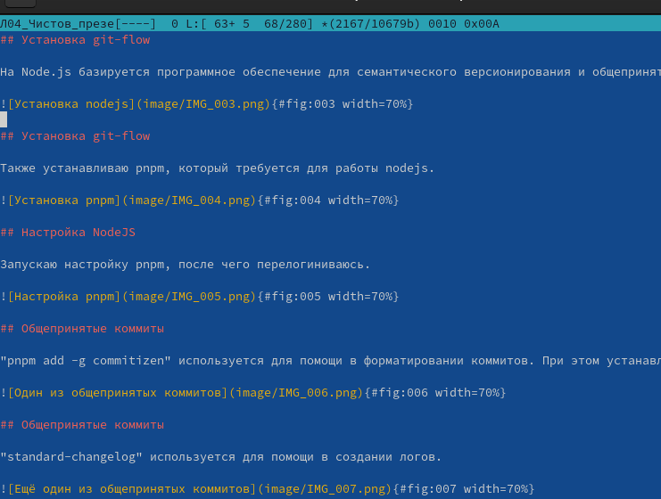

Синтаксис Markdown

## 2. Работа со встроенным редактором файлов в Midnight Commander

Перехожу в настроке McEdit, выбираю “Цветовыделение синтаксиса”.

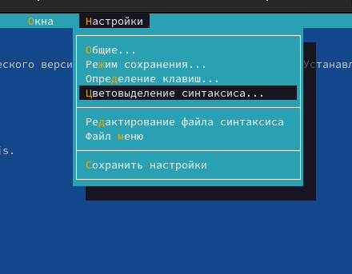

Меню McEdit

## 2. Работа со встроенным редактором файлов в Midnight Commander

Вижу, что сейчас выделяется синтаксис Markdown.

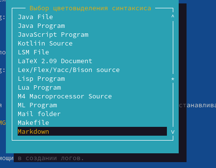

Меню McEdit

## 2. Работа со встроенным редактором файлов в Midnight Commander

Изменяю его на Unknown, тогда синтаксис не должен выделяться.

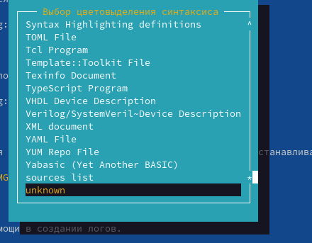

Меню McEdit

## 2. Работа со встроенным редактором файлов в Midnight Commander

Готово. Теперь я не могу разобраться в коде Markdown.

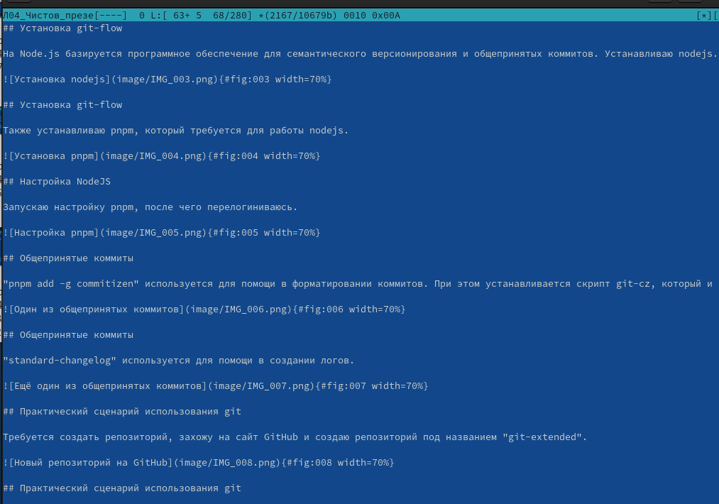

Нет синтаксиса Markdown

# Выводы

В результате выполненения данной работы я освоил основные возможности командной оболочки Midnight Commander. Приобрёл навыки практической работы по просмотру каталогов и файлов; манипуляций с ними.

# Список литературы

[Лабораторная работы №9](https://esystem.rudn.ru/pluginfile.php/2288091/mod_resource/content/5/007-lab_mc.pdf)